The following example results are from the 2022 Spanish Grand Prix.

You should follow the same process and show the same results, but for the 2022 Dutch Grand Prix

# Calculating Cumulative Lap times

In order to evaluate race strategy (including tyre and pit stop strategy) we need to know the relative position of each driver as the race progresses. We can derive this from the lap times of each driver. We start by calculating the cumulative lap time for each driver lap by lap. The cumulative lap time after the first lap will be the lap time for the first lap; the cumulative lap time at the end of the second lap will be the sum of the lap times for the first two laps and so on.

Start by creating a Python function to compute the cummulative lap time for a given driver at a given lap. The function will take as a parameter a single row from your Pandas data frame containing the lap data. This row will include the Driver and the LapNumber. Your function should return a floating point number representing the cummulative lap time for that driver up to the end of that lap in the race.

You can then apply that function to each row in your Pandas data frame to compute a new column representing the cummulative lap time (see example below).

|  | Time | Driver | LapTime | LapNumber | Stint | PitOutTime | PitInTime | Compound | TyreLife | TrackStatus | LapSeconds | CumulativeLapTime |
| --- | --- | --- | --- | --- | --- | --- | --- | --- | --- | --- | --- | --- |
| 0 | 0 days 01:03:42.951000 | VER | 0 days 00:01:29.739000 | 1 | 1 | 0 days 00:28:52.345000 | NaT | SOFT | 4 | 2 | 89.739 | 89.739 |
| 1 | 0 days 01:05:10.460000 | VER | 0 days 00:01:27.509000 | 2 | 1 | NaT | NaT | SOFT | 5 | 1 | 87.509 | 177.248 |
| 2 | 0 days 01:06:38.034000 | VER | 0 days 00:01:27.574000 | 3 | 1 | NaT | NaT | SOFT | 6 | 1 | 87.574 | 264.822 |
| 3 | 0 days 01:08:05.635000 | VER | 0 days 00:01:27.601000 | 4 | 1 | NaT | NaT | SOFT | 7 | 1 | 87.601 | 352.423 |
| 4 | 0 days 01:09:33.572000 | VER | 0 days 00:01:27.937000 | 5 | 1 | NaT | NaT | SOFT | 8 | 1 | 87.937 | 440.360 |
| ... | ... | ... | ... | ... | ... | ... | ... | ... | ... | ... | ... | ... |
| 1225 | 0 days 01:36:24.285000 | LEC | 0 days 00:01:27.210000 | 23 | 2 | NaT | NaT | MEDIUM | 2 | 1 | 87.210 | 2051.073 |
| 1226 | 0 days 01:37:51.481000 | LEC | 0 days 00:01:27.196000 | 24 | 2 | NaT | NaT | MEDIUM | 3 | 1 | 87.196 | 2138.269 |
| 1227 | 0 days 01:39:18.511000 | LEC | 0 days 00:01:27.030000 | 25 | 2 | NaT | NaT | MEDIUM | 4 | 1 | 87.030 | 2225.299 |
| 1228 | 0 days 01:40:45.790000 | LEC | 0 days 00:01:27.279000 | 26 | 2 | NaT | NaT | MEDIUM | 5 | 1 | 87.279 | 2312.578 |
| 1229 | 0 days 01:42:34.870000 | LEC | 0 days 00:01:49.080000 | 27 | 2 | NaT | 0 days 01:42:32.020000 | MEDIUM | 6 | 1 | 109.080 | 2421.658 |

1230 rows × 12 columns

# Calculate Driver Position relative to other drivers

If at the end of lap N, driver A's cummulative lap time is less than driver B's cummulative lap time then we can conclude that driver A is ahead of driver B at that point in the race. Our next goals is to therefore compute the position of each driver at the end of each lap based on their cumulative lap times.

Start by creating a Python function to compute the relative position for a given driver at a given lap. The function will take as a parameter a single row from your Pandas data frame containing the lap data. This row will contain the Driver, the LapNumber and the CumulativeLapTime. Your function should return an integer number representing the relative position of that driver up to that point in the race. The driver at the head of the race will have a position of 1, the next driver will have a position of 2 and so on.

You can then apply that function to each row in your Pandas data frame to compute a new column named Position (see example below).

|  | Time | Driver | LapTime | LapNumber | Stint | PitOutTime | PitInTime | Compound | TyreLife | TrackStatus | LapSeconds | CumulativeLapTime | Position |
| --- | --- | --- | --- | --- | --- | --- | --- | --- | --- | --- | --- | --- | --- |
| 0 | 0 days 01:03:42.951000 | VER | 0 days 00:01:29.739000 | 1 | 1 | 0 days 00:28:52.345000 | NaT | SOFT | 4 | 2 | 89.739 | 89.739 | 2 |
| 1 | 0 days 01:05:10.460000 | VER | 0 days 00:01:27.509000 | 2 | 1 | NaT | NaT | SOFT | 5 | 1 | 87.509 | 177.248 | 2 |
| 2 | 0 days 01:06:38.034000 | VER | 0 days 00:01:27.574000 | 3 | 1 | NaT | NaT | SOFT | 6 | 1 | 87.574 | 264.822 | 2 |
| 3 | 0 days 01:08:05.635000 | VER | 0 days 00:01:27.601000 | 4 | 1 | NaT | NaT | SOFT | 7 | 1 | 87.601 | 352.423 | 2 |
| 4 | 0 days 01:09:33.572000 | VER | 0 days 00:01:27.937000 | 5 | 1 | NaT | NaT | SOFT | 8 | 1 | 87.937 | 440.360 | 2 |
| ... | ... | ... | ... | ... | ... | ... | ... | ... | ... | ... | ... | ... | ... |
| 1225 | 0 days 01:36:24.285000 | LEC | 0 days 00:01:27.210000 | 23 | 2 | NaT | NaT | MEDIUM | 2 | 1 | 87.210 | 2051.073 | 1 |
| 1226 | 0 days 01:37:51.481000 | LEC | 0 days 00:01:27.196000 | 24 | 2 | NaT | NaT | MEDIUM | 3 | 1 | 87.196 | 2138.269 | 1 |
| 1227 | 0 days 01:39:18.511000 | LEC | 0 days 00:01:27.030000 | 25 | 2 | NaT | NaT | MEDIUM | 4 | 1 | 87.030 | 2225.299 | 1 |
| 1228 | 0 days 01:40:45.790000 | LEC | 0 days 00:01:27.279000 | 26 | 2 | NaT | NaT | MEDIUM | 5 | 1 | 87.279 | 2312.578 | 1 |
| 1229 | 0 days 01:42:34.870000 | LEC | 0 days 00:01:49.080000 | 27 | 2 | NaT | 0 days 01:42:32.020000 | MEDIUM | 6 | 1 | 109.080 | 2421.658 | 4 |

1230 rows × 13 columns

Display the position of each driver lap by lap in a tabular fashion (see example below):

| Driver LapNumber | ALB | ALO | BOT | GAS | HAM | LAT | LEC | MAG | MSC | NOR | OCO | PER | RIC | RUS | SAI | STR | TSU | VER | VET | ZHO |
| --- | --- | --- | --- | --- | --- | --- | --- | --- | --- | --- | --- | --- | --- | --- | --- | --- | --- | --- | --- | --- |
| 1 | 16 | 15 | 7 | 12 | 19 | 18 | 1 | 20 | 6 | 10 | 9 | 4 | 8 | 3 | 5 | 14 | 11 | 2 | 13 | 17 |
| 2 | 16 | 15 | 7 | 12 | 19 | 18 | 1 | 20 | 6 | 10 | 9 | 4 | 8 | 3 | 5 | 14 | 11 | 2 | 13 | 17 |
| 3 | 17 | 15 | 7 | 12 | 19 | 18 | 1 | 20 | 6 | 10 | 9 | 4 | 8 | 3 | 5 | 14 | 11 | 2 | 13 | 16 |
| 4 | 17 | 15 | 6 | 12 | 19 | 18 | 1 | 20 | 7 | 10 | 9 | 4 | 8 | 3 | 5 | 14 | 11 | 2 | 13 | 16 |
| 5 | 17 | 14 | 6 | 12 | 19 | 18 | 1 | 20 | 7 | 10 | 8 | 4 | 9 | 3 | 5 | 15 | 11 | 2 | 13 | 16 |
| 6 | 17 | 14 | 6 | 12 | 19 | 18 | 1 | 20 | 8 | 10 | 7 | 4 | 9 | 3 | 5 | 16 | 11 | 2 | 13 | 15 |
| 7 | 17 | 13 | 5 | 12 | 19 | 18 | 1 | 20 | 7 | 9 | 6 | 4 | 8 | 3 | 11 | 16 | 10 | 2 | 14 | 15 |
| 8 | 17 | 13 | 5 | 12 | 19 | 18 | 1 | 20 | 7 | 9 | 6 | 4 | 8 | 3 | 11 | 16 | 10 | 2 | 14 | 15 |
| 9 | 17 | 12 | 5 | 13 | 19 | 18 | 1 | 20 | 7 | 8 | 6 | 3 | 9 | 2 | 11 | 16 | 10 | 4 | 14 | 15 |
| 10 | 17 | 13 | 5 | 14 | 19 | 18 | 1 | 20 | 8 | 7 | 6 | 3 | 9 | 2 | 11 | 15 | 10 | 4 | 12 | 16 |
| 11 | 14 | 16 | 5 | 17 | 19 | 13 | 1 | 20 | 8 | 7 | 6 | 4 | 10 | 2 | 15 | 12 | 9 | 3 | 11 | 18 |
| 12 | 19 | 13 | 5 | 16 | 18 | 12 | 1 | 20 | 8 | 7 | 6 | 4 | 15 | 2 | 11 | 10 | 14 | 3 | 9 | 17 |
| 13 | 18 | 11 | 5 | 15 | 17 | 19 | 1 | 20 | 14 | 9 | 6 | 2 | 13 | 3 | 10 | 8 | 12 | 4 | 7 | 16 |
| 14 | 18 | 12 | 3 | 15 | 17 | 19 | 1 | 20 | 14 | 10 | 7 | 2 | 13 | 4 | 8 | 9 | 11 | 5 | 6 | 16 |
| 15 | 17 | 11 | 5 | 14 | 16 | 19 | 1 | 20 | 13 | 9 | 7 | 2 | 12 | 3 | 8 | 18 | 10 | 4 | 6 | 15 |
| 16 | 18 | 11 | 5 | 14 | 16 | 19 | 1 | 20 | 13 | 9 | 7 | 2 | 12 | 3 | 8 | 17 | 10 | 4 | 6 | 15 |
| 17 | 18 | 11 | 5 | 14 | 16 | 19 | 1 | 20 | 13 | 9 | 6 | 2 | 12 | 3 | 8 | 17 | 10 | 4 | 7 | 15 |
| 18 | 18 | 11 | 5 | 14 | 16 | 19 | 1 | 20 | 13 | 9 | 6 | 4 | 12 | 2 | 7 | 17 | 10 | 3 | 8 | 15 |
| 19 | 18 | 11 | 5 | 14 | 16 | 19 | 1 | 20 | 12 | 9 | 6 | 4 | 13 | 2 | 7 | 17 | 10 | 3 | 8 | 15 |
| 20 | 18 | 11 | 5 | 14 | 16 | 19 | 1 | 20 | 12 | 9 | 6 | 4 | 13 | 2 | 7 | 17 | 10 | 3 | 8 | 15 |
| 21 | 19 | 11 | 5 | 14 | 16 | 18 | 1 | 20 | 12 | 8 | 6 | 4 | 13 | 2 | 7 | 17 | 9 | 3 | 10 | 15 |
| 22 | 19 | 10 | 5 | 14 | 16 | 18 | 1 | 20 | 11 | 8 | 6 | 4 | 12 | 2 | 7 | 15 | 9 | 3 | 17 | 13 |
| 23 | 18 | 10 | 5 | 14 | 19 | 17 | 1 | 20 | 11 | 8 | 6 | 4 | 12 | 2 | 7 | 15 | 9 | 3 | 16 | 13 |
| 24 | 19 | 10 | 5 | 14 | 18 | 17 | 1 | 20 | 11 | 8 | 7 | 4 | 12 | 2 | 6 | 15 | 9 | 3 | 16 | 13 |
| 25 | 19 | 10 | 5 | 14 | 17 | 18 | 1 | 20 | 11 | 8 | 7 | 4 | 12 | 2 | 6 | 15 | 9 | 3 | 16 | 13 |
| 26 | 20 | 10 | 5 | 14 | 17 | 18 | 1 | 19 | 11 | 8 | 7 | 4 | 12 | 2 | 6 | 15 | 9 | 3 | 16 | 13 |
| 27 | 20 | 10 | 5 | 14 | 16 | 19 | 4 | 18 | 11 | 8 | 7 | 3 | 12 | 1 | 6 | 17 | 9 | 2 | 15 | 13 |
| 28 | 19 | 9 | 4 | 12 | 14 | 18 | <NA> | 16 | 10 | 7 | 6 | 2 | 11 | 1 | 5 | 17 | 8 | 3 | 13 | 15 |
| 29 | 18 | 9 | 3 | 14 | 13 | 16 | <NA> | 17 | 10 | 7 | 6 | 2 | 11 | 1 | 5 | 15 | 8 | 4 | 12 | <NA> |
| 30 | 17 | 9 | 3 | 14 | 12 | 16 | <NA> | 18 | 11 | 7 | 6 | 2 | 10 | 1 | 5 | 15 | 8 | 4 | 13 | <NA> |
| 31 | 17 | 9 | 4 | 14 | 10 | 16 | <NA> | 18 | 13 | 7 | 6 | 1 | 11 | 2 | 5 | 15 | 8 | 3 | 12 | <NA> |
| 32 | 17 | 11 | 4 | 14 | 9 | 16 | <NA> | 18 | 12 | 6 | 5 | 1 | 13 | 2 | 7 | 15 | 8 | 3 | 10 | <NA> |
| 33 | 17 | 11 | 4 | 14 | 8 | 16 | <NA> | 18 | 12 | 6 | 5 | 1 | 13 | 2 | 7 | 15 | 10 | 3 | 9 | <NA> |
| 34 | 17 | 10 | 4 | 14 | 7 | 16 | <NA> | 18 | 12 | 9 | 5 | 1 | 13 | 2 | 6 | 15 | 11 | 3 | 8 | <NA> |
| 35 | 17 | 10 | 4 | 14 | 7 | 16 | <NA> | 18 | 12 | 9 | 6 | 1 | 13 | 2 | 5 | 15 | 11 | 3 | 8 | <NA> |
| 36 | 17 | 10 | 4 | 14 | 6 | 16 | <NA> | 18 | 12 | 9 | 7 | 1 | 13 | 3 | 5 | 15 | 11 | 2 | 8 | <NA> |
| 37 | 17 | 10 | 4 | 14 | 6 | 16 | <NA> | 18 | 12 | 9 | 7 | 1 | 13 | 3 | 5 | 15 | 11 | 2 | 8 | <NA> |
| 38 | 17 | 10 | 4 | 14 | 6 | 16 | <NA> | 18 | 12 | 9 | 7 | 2 | 13 | 3 | 5 | 15 | 11 | 1 | 8 | <NA> |
| 39 | 17 | 10 | 4 | 14 | 6 | 16 | <NA> | 18 | 12 | 8 | 7 | 2 | 13 | 3 | 5 | 15 | 11 | 1 | 9 | <NA> |
| 40 | 18 | 10 | 4 | 14 | 6 | 16 | <NA> | 17 | 12 | 8 | 7 | 2 | 13 | 3 | 5 | 15 | 11 | 1 | 9 | <NA> |
| 41 | 18 | 10 | 4 | 14 | 6 | 16 | <NA> | 17 | 12 | 8 | 7 | 2 | 13 | 3 | 5 | 15 | 11 | 1 | 9 | <NA> |
| 42 | 18 | 9 | 4 | 14 | 6 | 16 | <NA> | 17 | 12 | 8 | 7 | 2 | 13 | 3 | 5 | 15 | 10 | 1 | 11 | <NA> |
| 43 | 18 | 9 | 4 | 13 | 6 | 16 | <NA> | 17 | 11 | 8 | 7 | 2 | 12 | 3 | 5 | 15 | 10 | 1 | 14 | <NA> |
| 44 | 18 | 9 | 4 | 13 | 6 | 16 | <NA> | 17 | 11 | 8 | 7 | 2 | 12 | 3 | 5 | 15 | 10 | 1 | 14 | <NA> |
| 45 | 18 | 9 | 4 | 14 | 6 | 16 | <NA> | 17 | 11 | 8 | 7 | 1 | 12 | 3 | 5 | 15 | 10 | 2 | 13 | <NA> |
| 46 | 18 | 9 | 4 | 14 | 5 | 16 | <NA> | 17 | 11 | 8 | 6 | 1 | 12 | 3 | 7 | 15 | 10 | 2 | 13 | <NA> |
| 47 | 18 | 9 | 4 | 14 | 5 | 15 | <NA> | 16 | 11 | 8 | 7 | 1 | 12 | 3 | 6 | 17 | 10 | 2 | 13 | <NA> |
| 48 | 18 | 9 | 4 | 14 | 5 | 15 | <NA> | 16 | 11 | 8 | 7 | 1 | 13 | 3 | 6 | 17 | 10 | 2 | 12 | <NA> |
| 49 | 18 | 9 | 4 | 14 | 7 | 15 | <NA> | 16 | 11 | 8 | 6 | 2 | 13 | 3 | 5 | 17 | 10 | 1 | 12 | <NA> |
| 50 | 18 | 9 | 4 | 14 | 7 | 15 | <NA> | 16 | 11 | 8 | 6 | 2 | 13 | 3 | 5 | 17 | 10 | 1 | 12 | <NA> |
| 51 | 18 | 9 | 4 | 14 | 6 | 17 | <NA> | 16 | 11 | 8 | 7 | 2 | 13 | 3 | 5 | 15 | 10 | 1 | 12 | <NA> |
| 52 | 18 | 8 | 3 | 14 | 6 | 17 | <NA> | 16 | 11 | 10 | 7 | 2 | 13 | 4 | 5 | 15 | 9 | 1 | 12 | <NA> |
| 53 | 18 | 7 | 4 | 14 | 6 | 17 | <NA> | 16 | 10 | 9 | 8 | 2 | 13 | 3 | 5 | 15 | 11 | 1 | 12 | <NA> |
| 54 | 18 | 10 | 4 | 14 | 6 | 17 | <NA> | 16 | 9 | 8 | 7 | 2 | 13 | 3 | 5 | 15 | 11 | 1 | 12 | <NA> |
| 55 | 18 | 9 | 4 | 14 | 6 | 17 | <NA> | 16 | 10 | 8 | 7 | 2 | 13 | 3 | 5 | 15 | 11 | 1 | 12 | <NA> |
| 56 | 18 | 9 | 4 | 14 | 6 | 17 | <NA> | 16 | 11 | 8 | 7 | 2 | 13 | 3 | 5 | 15 | 10 | 1 | 12 | <NA> |
| 57 | 18 | 9 | 4 | 14 | 6 | 17 | <NA> | 16 | 11 | 8 | 7 | 2 | 13 | 3 | 5 | 15 | 10 | 1 | 12 | <NA> |
| 58 | 18 | 9 | 6 | 14 | 5 | 17 | <NA> | 16 | 11 | 8 | 7 | 2 | 13 | 3 | 4 | 15 | 10 | 1 | 12 | <NA> |
| 59 | 18 | 9 | 6 | 14 | 5 | 17 | <NA> | 16 | 12 | 8 | 7 | 2 | 13 | 3 | 4 | 15 | 10 | 1 | 11 | <NA> |
| 60 | 18 | 9 | 6 | 14 | 4 | 17 | <NA> | 16 | 12 | 8 | 7 | 2 | 13 | 3 | 5 | 15 | 10 | 1 | 11 | <NA> |
| 61 | 18 | 9 | 6 | 14 | 4 | 17 | <NA> | 16 | 12 | 8 | 7 | 2 | 13 | 3 | 5 | 15 | 10 | 1 | 11 | <NA> |
| 62 | 18 | 9 | 6 | 14 | 4 | 16 | <NA> | 17 | 12 | 8 | 7 | 2 | 13 | 3 | 5 | 15 | 10 | 1 | 11 | <NA> |
| 63 | 18 | 9 | 6 | 14 | 4 | 16 | <NA> | 17 | 12 | 8 | 7 | 2 | 13 | 3 | 5 | 15 | 10 | 1 | 11 | <NA> |
| 64 | 18 | 9 | 6 | 14 | 4 | 16 | <NA> | 17 | 13 | 8 | 7 | 2 | 12 | 3 | 5 | 15 | 10 | 1 | 11 | <NA> |
| 65 | <NA> | 9 | 6 | 13 | 5 | <NA> | <NA> | <NA> | 14 | 8 | 7 | 2 | 12 | 3 | 4 | 15 | 10 | 1 | 11 | <NA> |
| 66 | <NA> | <NA> | 6 | <NA> | 5 | <NA> | <NA> | <NA> | <NA> | 8 | 7 | 2 | <NA> | 3 | 4 | <NA> | <NA> | 1 | <NA> | <NA> |

Plot how position changes during a race for a particular driver.

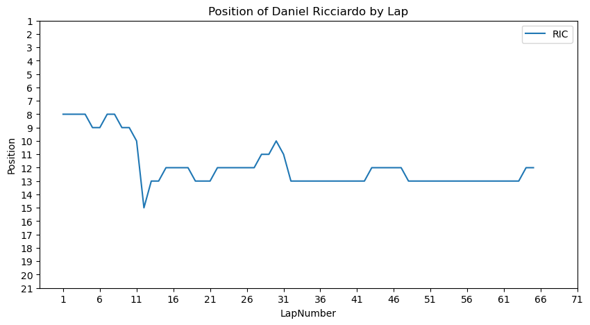

Create a list of the drivers in race order at the end of the first lap.

```
['LEC', 'VER', 'RUS', 'PER', 'SAI', 'MSC', 'BOT', 'RIC', 'OCO', 'NOR', 'TSU', 'GAS', 'VET', 'STR', 'ALO', 'ALB', 'ZHO', 'LAT', 'HAM', 'MAG']
```

Use a for loop to iterate over this list and plot the changing positions of each driver lap by lap all together in a single plot (with Legend)

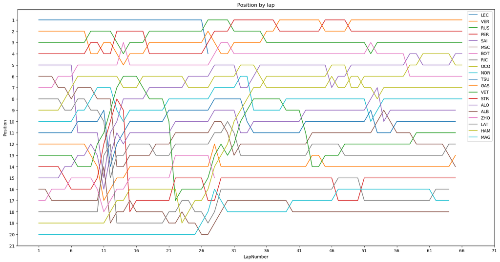

# Join with previous lap for that driver

To determine overtakes and other important statistics we need to combine data for a particular lap (for a particular driver) with the data for the previous lap for that same driver.

First we need to know which row in the data frame corresponds to the previous lap for the same driver.

Start by creating a Python function to compute the index of the row that corresponds to the previous lap for a given driver at a given lap. The function will take as a parameter a single row from your Pandas data frame containing the lap data. This row will contain the Driver and the LapNumber. Your function should return an integer number representing the index of the row that contains the same driver but on the previous lap (LapNumber-1). If no such row exists (for example for the first lap) then your function should instead return NaN (Not a Number).

You can then apply that function to each row in your Pandas data frame to compute a new column named PreviousIndex (see example below).

|  | Time | Driver | LapTime | LapNumber | Stint | PitOutTime | PitInTime | Compound | TyreLife | TrackStatus | LapSeconds | CumulativeLapTime | Position | PreviousIndex |
| --- | --- | --- | --- | --- | --- | --- | --- | --- | --- | --- | --- | --- | --- | --- |
| 0 | 0 days 01:03:42.951000 | VER | 0 days 00:01:29.739000 | 1 | 1 | 0 days 00:28:52.345000 | NaT | SOFT | 4 | 2 | 89.739 | 89.739 | 2 | NaN |
| 1 | 0 days 01:05:10.460000 | VER | 0 days 00:01:27.509000 | 2 | 1 | NaT | NaT | SOFT | 5 | 1 | 87.509 | 177.248 | 2 | 0.0 |
| 2 | 0 days 01:06:38.034000 | VER | 0 days 00:01:27.574000 | 3 | 1 | NaT | NaT | SOFT | 6 | 1 | 87.574 | 264.822 | 2 | 1.0 |
| 3 | 0 days 01:08:05.635000 | VER | 0 days 00:01:27.601000 | 4 | 1 | NaT | NaT | SOFT | 7 | 1 | 87.601 | 352.423 | 2 | 2.0 |
| 4 | 0 days 01:09:33.572000 | VER | 0 days 00:01:27.937000 | 5 | 1 | NaT | NaT | SOFT | 8 | 1 | 87.937 | 440.360 | 2 | 3.0 |
| ... | ... | ... | ... | ... | ... | ... | ... | ... | ... | ... | ... | ... | ... | ... |
| 1225 | 0 days 01:36:24.285000 | LEC | 0 days 00:01:27.210000 | 23 | 2 | NaT | NaT | MEDIUM | 2 | 1 | 87.210 | 2051.073 | 1 | 1224.0 |
| 1226 | 0 days 01:37:51.481000 | LEC | 0 days 00:01:27.196000 | 24 | 2 | NaT | NaT | MEDIUM | 3 | 1 | 87.196 | 2138.269 | 1 | 1225.0 |
| 1227 | 0 days 01:39:18.511000 | LEC | 0 days 00:01:27.030000 | 25 | 2 | NaT | NaT | MEDIUM | 4 | 1 | 87.030 | 2225.299 | 1 | 1226.0 |
| 1228 | 0 days 01:40:45.790000 | LEC | 0 days 00:01:27.279000 | 26 | 2 | NaT | NaT | MEDIUM | 5 | 1 | 87.279 | 2312.578 | 1 | 1227.0 |
| 1229 | 0 days 01:42:34.870000 | LEC | 0 days 00:01:49.080000 | 27 | 2 | NaT | 0 days 01:42:32.020000 | MEDIUM | 6 | 1 | 109.080 | 2421.658 | 4 | 1228.0 |

1230 rows × 14 columns

We can then use the PreviousIndex column to join our lap data with **itself** such that each row in the result will contain data for both a lap and the previous lap for that driver.

The columns corresponding to the previous lap should have a suffix of "_previous".

|  | Time | Driver | LapTime | LapNumber | Stint | PitOutTime | PitInTime | Compound | TyreLife | TrackStatus | LapSeconds | CumulativeLapTime | Position | PreviousIndex | Time_previous | Driver_previous | LapTime_previous | LapNumber_previous | Stint_previous | PitOutTime_previous | PitInTime_previous | Compound_previous | TyreLife_previous | TrackStatus_previous | LapSeconds_previous | CumulativeLapTime_previous | Position_previous | PreviousIndex_previous |
| --- | --- | --- | --- | --- | --- | --- | --- | --- | --- | --- | --- | --- | --- | --- | --- | --- | --- | --- | --- | --- | --- | --- | --- | --- | --- | --- | --- | --- |
| 1 | 0 days 01:05:10.460000 | VER | 0 days 00:01:27.509000 | 2 | 1 | NaT | NaT | SOFT | 5 | 1 | 87.509 | 177.248 | 2 | 0.0 | 0 days 01:03:42.951000 | VER | 0 days 00:01:29.739000 | 1 | 1 | 0 days 00:28:52.345000 | NaT | SOFT | 4 | 2 | 89.739 | 89.739 | 2 | NaN |
| 2 | 0 days 01:06:38.034000 | VER | 0 days 00:01:27.574000 | 3 | 1 | NaT | NaT | SOFT | 6 | 1 | 87.574 | 264.822 | 2 | 1.0 | 0 days 01:05:10.460000 | VER | 0 days 00:01:27.509000 | 2 | 1 | NaT | NaT | SOFT | 5 | 1 | 87.509 | 177.248 | 2 | 0.0 |
| 3 | 0 days 01:08:05.635000 | VER | 0 days 00:01:27.601000 | 4 | 1 | NaT | NaT | SOFT | 7 | 1 | 87.601 | 352.423 | 2 | 2.0 | 0 days 01:06:38.034000 | VER | 0 days 00:01:27.574000 | 3 | 1 | NaT | NaT | SOFT | 6 | 1 | 87.574 | 264.822 | 2 | 1.0 |
| 4 | 0 days 01:09:33.572000 | VER | 0 days 00:01:27.937000 | 5 | 1 | NaT | NaT | SOFT | 8 | 1 | 87.937 | 440.360 | 2 | 3.0 | 0 days 01:08:05.635000 | VER | 0 days 00:01:27.601000 | 4 | 1 | NaT | NaT | SOFT | 7 | 1 | 87.601 | 352.423 | 2 | 2.0 |
| 5 | 0 days 01:11:01.333000 | VER | 0 days 00:01:27.761000 | 6 | 1 | NaT | NaT | SOFT | 9 | 1 | 87.761 | 528.121 | 2 | 4.0 | 0 days 01:09:33.572000 | VER | 0 days 00:01:27.937000 | 5 | 1 | NaT | NaT | SOFT | 8 | 1 | 87.937 | 440.360 | 2 | 3.0 |
| ... | ... | ... | ... | ... | ... | ... | ... | ... | ... | ... | ... | ... | ... | ... | ... | ... | ... | ... | ... | ... | ... | ... | ... | ... | ... | ... | ... | ... |
| 1225 | 0 days 01:36:24.285000 | LEC | 0 days 00:01:27.210000 | 23 | 2 | NaT | NaT | MEDIUM | 2 | 1 | 87.210 | 2051.073 | 1 | 1224.0 | 0 days 01:34:57.075000 | LEC | 0 days 00:01:45.687000 | 22 | 2 | 0 days 01:33:30.392000 | NaT | MEDIUM | 1 | 1 | 105.687 | 1963.863 | 1 | 1223.0 |
| 1226 | 0 days 01:37:51.481000 | LEC | 0 days 00:01:27.196000 | 24 | 2 | NaT | NaT | MEDIUM | 3 | 1 | 87.196 | 2138.269 | 1 | 1225.0 | 0 days 01:36:24.285000 | LEC | 0 days 00:01:27.210000 | 23 | 2 | NaT | NaT | MEDIUM | 2 | 1 | 87.210 | 2051.073 | 1 | 1224.0 |
| 1227 | 0 days 01:39:18.511000 | LEC | 0 days 00:01:27.030000 | 25 | 2 | NaT | NaT | MEDIUM | 4 | 1 | 87.030 | 2225.299 | 1 | 1226.0 | 0 days 01:37:51.481000 | LEC | 0 days 00:01:27.196000 | 24 | 2 | NaT | NaT | MEDIUM | 3 | 1 | 87.196 | 2138.269 | 1 | 1225.0 |
| 1228 | 0 days 01:40:45.790000 | LEC | 0 days 00:01:27.279000 | 26 | 2 | NaT | NaT | MEDIUM | 5 | 1 | 87.279 | 2312.578 | 1 | 1227.0 | 0 days 01:39:18.511000 | LEC | 0 days 00:01:27.030000 | 25 | 2 | NaT | NaT | MEDIUM | 4 | 1 | 87.030 | 2225.299 | 1 | 1226.0 |
| 1229 | 0 days 01:42:34.870000 | LEC | 0 days 00:01:49.080000 | 27 | 2 | NaT | 0 days 01:42:32.020000 | MEDIUM | 6 | 1 | 109.080 | 2421.658 | 4 | 1228.0 | 0 days 01:40:45.790000 | LEC | 0 days 00:01:27.279000 | 26 | 2 | NaT | NaT | MEDIUM | 5 | 1 | 87.279 | 2312.578 | 1 | 1227.0 |

1210 rows × 28 columns

# Compute Pit stop durations based on joined lap data

We can now use this joined lap data to compute the duration of each pit stop. Note this is not the time spent stationary (typically around 3 seconds), but the entire time from when they entered the pit lane until they leave the pit lane (typically around 20 seconds).

To compute the pit stop time we calculate the difference between when they enter the pit lane (as part of the previous lap) and when they exist the pit lane (as part of the next lap).

Display a list of only those laps when a pit stop was taken.

|  | Driver | LapNumber | PitTime |
| --- | --- | --- | --- |
| 13 | VER | 14 | 22.190 |
| 28 | VER | 29 | 21.969 |
| 44 | VER | 45 | 22.021 |
| 83 | PER | 18 | 22.016 |
| 103 | PER | 38 | 21.592 |
| 119 | PER | 54 | 21.678 |
| 145 | RUS | 14 | 22.029 |
| 168 | RUS | 37 | 22.021 |
| 183 | RUS | 52 | 22.821 |
| 208 | SAI | 11 | 22.260 |
| 229 | SAI | 32 | 21.842 |
| 243 | SAI | 46 | 22.209 |
| 265 | HAM | 2 | 31.078 |
| 286 | HAM | 23 | 22.052 |
| 312 | HAM | 49 | 22.224 |
| 344 | BOT | 15 | 22.972 |
| 364 | BOT | 35 | 22.526 |
| 409 | OCO | 14 | 22.106 |
| 431 | OCO | 36 | 22.903 |
| 448 | OCO | 53 | 22.040 |
| 474 | NOR | 13 | 21.929 |
| 495 | NOR | 34 | 23.285 |
| 513 | NOR | 52 | 22.133 |
| 538 | ALO | 11 | 22.389 |
| 559 | ALO | 32 | 21.936 |
| 581 | ALO | 54 | 25.402 |
| 604 | TSU | 12 | 23.071 |
| 625 | TSU | 33 | 22.781 |
| 645 | TSU | 53 | 22.337 |
| 679 | VET | 22 | 22.469 |
| 700 | VET | 43 | 22.475 |
| 734 | RIC | 12 | 22.118 |
| 754 | RIC | 32 | 22.390 |
| 771 | RIC | 49 | 22.134 |
| 798 | GAS | 11 | 21.886 |
| 817 | GAS | 30 | 27.924 |
| 834 | GAS | 47 | 21.916 |
| 865 | MSC | 13 | 23.572 |
| 883 | MSC | 31 | 23.099 |
| 932 | STR | 15 | 22.858 |
| 945 | STR | 28 | 23.398 |
| 964 | STR | 47 | 23.799 |
| 995 | LAT | 13 | 23.270 |
| 1009 | LAT | 27 | 22.302 |
| 1033 | LAT | 51 | 22.757 |
| 1048 | MAG | 2 | 29.619 |
| 1076 | MAG | 30 | 23.839 |
| 1122 | ALB | 12 | 23.406 |
| 1136 | ALB | 26 | 22.655 |
| 1156 | ALB | 46 | 23.251 |
| 1165 | ALB | 55 | 23.442 |
| 1185 | ZHO | 11 | 23.142 |
| 1224 | LEC | 22 | 21.739 |

Show a box plot of the pit stop times for each driver (excluding fliers)

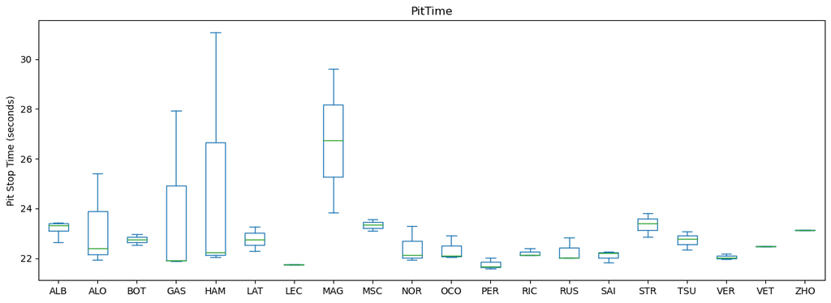

# Compute Overtakes based on joined lap data

Next we can use the *joined* lap data to help calculate when a driver overtook another driver. We say that driver A overtook driver B on lap N if driver A was behind driver B on the previous lap (N-1) but was then ahead of driver B by the end of the next lap (N).

Start by creating a Python function to compute the drivers that were overtaken by a particular driver on a particular lap. The function will take as a parameter a single row from your joined lap data frame (containing the lap data from both the previous and current lap). This row will contain the Driver, LapNumber, current Position and Position_previous (from the previous lap). Your function should return the Drivers from rows of the joined lap data that match the LapNumber and such that the driver was behind in the previous lap but ahead in the next lap.

You can then use a for loop to iterate through the rows of the joined lap data frame (sorted by LapNumber and then driver Position) and call the overtakes function to determine which if any drivers were overtaken by that driver on that lap. For those cases where there was an overtake, print out the names of both drivers involved and the lap number on which it occurred. Note that a driver may overtake more than one other driver per lap.

```
On lap 3 ZHO overtook ALB
On lap 4 BOT overtook MSC
On lap 5 OCO overtook RIC
On lap 5 ALO overtook STR
On lap 6 OCO overtook MSC
On lap 6 ZHO overtook STR
On lap 7 BOT overtook SAI
On lap 7 OCO overtook SAI
On lap 7 MSC overtook SAI
On lap 7 RIC overtook SAI
On lap 7 NOR overtook SAI
On lap 7 TSU overtook SAI
On lap 7 ALO overtook VET
On lap 9 RUS overtook VER
On lap 9 PER overtook VER
On lap 9 NOR overtook RIC
On lap 9 ALO overtook GAS
On lap 10 NOR overtook MSC
On lap 10 VET overtook ALO
On lap 10 VET overtook GAS
On lap 10 STR overtook ZHO
On lap 11 VER overtook PER
On lap 11 TSU overtook RIC
On lap 11 VET overtook SAI
On lap 11 STR overtook SAI
On lap 11 STR overtook ALO
On lap 11 STR overtook GAS
On lap 11 LAT overtook SAI
On lap 11 LAT overtook ALO
On lap 11 LAT overtook GAS
On lap 11 LAT overtook ALB
On lap 11 LAT overtook ZHO
On lap 11 ALB overtook SAI
On lap 11 ALB overtook ALO
On lap 11 ALB overtook GAS
On lap 11 ALB overtook ZHO
On lap 12 VET overtook TSU
On lap 12 VET overtook RIC
On lap 12 STR overtook TSU
On lap 12 STR overtook RIC
```

[output cut: 138 more lines]

```
On lap 53 NOR overtook TSU
On lap 53 MSC overtook TSU
On lap 54 OCO overtook ALO
On lap 54 NOR overtook ALO
On lap 54 MSC overtook ALO
On lap 55 ALO overtook MSC
On lap 56 TSU overtook MSC
On lap 58 SAI overtook BOT
On lap 58 HAM overtook BOT
On lap 59 VET overtook MSC
On lap 60 HAM overtook SAI
On lap 62 LAT overtook MAG
On lap 64 RIC overtook MSC
On lap 65 SAI overtook HAM
On lap 65 GAS overtook MSC
```

# Challenge Question: The Undercut

The following is a challenge exercise. It is designed to identify outstanding levels of achievement (i.e. for those students aiming to achieve a grade of 7).

You can skip it if you are not seeking such a challenge.

You can find plenty of information on the web around the race/pitstop strategy referred to as "Undercutting".

- https://f1chronicle.com/how-the-undercut-works-in-f1/
- https://au.motorsport.com/f1/news/f1-strategy-explained-whats-an-undercut-overcut-a-drs-train-and-more/10500436/
- https://thesportsrush.com/f1-news-undercut-f1-what-is-the-meaning-of-undercut-in-formula-1-complete-explanation/

If a driver is stuck behind a driver immediately ahead and is unable to get past then on the track, they can instead use a different tactic to get ahead of their opponent. The strategy involves coming in for a pit stop in some lap before their opponent. The pit stops takes around 20 seconds to complete, so by the time that car returns to the track they will be way behind their opponent. However, if they time it well, they will come back out onto the track in "free air" (i.e. without another driver directly ahead). They will then be able to exploit their fresh new tires and go as fast as the car is able without being slowed down by a car immediately in front. They will therefore hopefully close the gap on their original opponent ahead such that when their opponent eventually also takes their pit stop (normally one or two laps latter), by the time they reenter the track, we can get ahead of them.

Based on the data we have available, how might you identify when an undercut has occurred?